# Panel Data and Fixed Effects Methods for Ecology

## Data Filtering

A very common activity when you are analyzing data is to take subsets, be they subsets of rows or one or more columns (or both simultaneously). Gaining experience at this kind of filtering will make you much more efficient.

### Activity

To give you some practice filtering, filter your data in the following ways using base R functions. We will talk about they tidyverse version of these functions next week, but if you want to get ahead you can google these and try them here. You do not need to save the resulting `data.frame`s.

1. All *Pardosa ramulosa*
2. All females of both species
3. Body mass and sex for *Nephila clavipes*
4. Rows 1-50 (either using base R or the `slice()` function from tidyverse [use `?slice` to load the help file])
5. Mass of the largest female (by mass) in each species
6. Male *Pardosa ramulosa* with body lengths less than 4 or greater than 6

```r
#FIXME
# 1
M[M$Species == "Pardosa_ramulosa", ]
```

```
## # A tibble: 100 x 4
##    Species          Sex   BodyLength BodyMass
##    <chr>            <chr>      <dbl>    <dbl>
##  1 Pardosa_ramulosa M           3.67   0.0534
##  2 Pardosa_ramulosa M           4.96   0.169
##  3 Pardosa_ramulosa M           5.21   0.224
##  4 Pardosa_ramulosa M           5.18   0.106
##  5 Pardosa_ramulosa M           4.79   0.147
##  6 Pardosa_ramulosa M           6.05   0.221
##  7 Pardosa_ramulosa M           3.97   0.0986
##  8 Pardosa_ramulosa M           2.75   0.0249
##  9 Pardosa_ramulosa M           4.22   0.0716
## 10 Pardosa_ramulosa M           3.41   0.0434
## # … with 90 more rows
```

```r
M %>% filter(Species == "Pardosa_ramulosa")
```

```
## # A tibble: 100 x 4
##    Species          Sex   BodyLength BodyMass
##    <chr>            <chr>      <dbl>    <dbl>
##  1 Pardosa_ramulosa M           3.67   0.0534
##  2 Pardosa_ramulosa M           4.96   0.169
##  3 Pardosa_ramulosa M           5.21   0.224
##  4 Pardosa_ramulosa M           5.18   0.106
##  5 Pardosa_ramulosa M           4.79   0.147
##  6 Pardosa_ramulosa M           6.05   0.221
##  7 Pardosa_ramulosa M           3.97   0.0986
##  8 Pardosa_ramulosa M           2.75   0.0249
##  9 Pardosa_ramulosa M           4.22   0.0716
## 10 Pardosa_ramulosa M           3.41   0.0434
## # … with 90 more rows
```

```r
# 2
M[M$Sex == "F", ]
```

```
## # A tibble: 100 x 4
##    Species          Sex   BodyLength BodyMass
##    <chr>            <chr>      <dbl>    <dbl>
##  1 Pardosa_ramulosa F           6.44   0.319
##  2 Pardosa_ramulosa F           5.93   0.465
##  3 Pardosa_ramulosa F           4.59   0.0679
##  4 Pardosa_ramulosa F           6.91   0.252
##  5 Pardosa_ramulosa F           6.12   0.113
##  6 Pardosa_ramulosa F           7.91   0.255
##  7 Pardosa_ramulosa F           6.04   0.252
##  8 Pardosa_ramulosa F           6.80   0.201
##  9 Pardosa_ramulosa F           5.14   0.161
## 10 Pardosa_ramulosa F           4.94   0.0960
## # … with 90 more rows
```

```r
M %>% filter(Sex == "F")
```

```
## # A tibble: 100 x 4
##    Species          Sex   BodyLength BodyMass
##    <chr>            <chr>      <dbl>    <dbl>
##  1 Pardosa_ramulosa F           6.44   0.319
##  2 Pardosa_ramulosa F           5.93   0.465
##  3 Pardosa_ramulosa F           4.59   0.0679
##  4 Pardosa_ramulosa F           6.91   0.252
##  5 Pardosa_ramulosa F           6.12   0.113
##  6 Pardosa_ramulosa F           7.91   0.255
##  7 Pardosa_ramulosa F           6.04   0.252
##  8 Pardosa_ramulosa F           6.80   0.201
##  9 Pardosa_ramulosa F           5.14   0.161
## 10 Pardosa_ramulosa F           4.94   0.0960
## # … with 90 more rows
```

```r
# 3
M[M$Species == "Nephila_clavipes", c("BodyMass", "Sex")]
```

```
## # A tibble: 100 x 2
##    BodyMass Sex
##       <dbl> <chr>
##  1     6.36 M
##  2    12.1  M
##  3     6.39 M
##  4     3.91 M
##  5     2.01 M
##  6    12.8  M
##  7     2.44 M
##  8     7.69 M
##  9    11.6  M
## 10     2.93 M
## # … with 90 more rows
```

```r
M %>% filter(Species == "Nephila_clavipes") %>%
  select(BodyMass, Sex)
```

```
## # A tibble: 100 x 2
##    BodyMass Sex
##       <dbl> <chr>
##  1     6.36 M
##  2    12.1  M
##  3     6.39 M
##  4     3.91 M
##  5     2.01 M
##  6    12.8  M
##  7     2.44 M
##  8     7.69 M
##  9    11.6  M
## 10     2.93 M
## # … with 90 more rows
```

```r
# 4
M[1:50, ]
```

```
## # A tibble: 50 x 4
##    Species          Sex   BodyLength BodyMass
##    <chr>            <chr>      <dbl>    <dbl>
##  1 Pardosa_ramulosa M           3.67   0.0534
##  2 Pardosa_ramulosa M           4.96   0.169
##  3 Pardosa_ramulosa M           5.21   0.224
##  4 Pardosa_ramulosa M           5.18   0.106
##  5 Pardosa_ramulosa M           4.79   0.147
##  6 Pardosa_ramulosa M           6.05   0.221
##  7 Pardosa_ramulosa M           3.97   0.0986
##  8 Pardosa_ramulosa M           2.75   0.0249
##  9 Pardosa_ramulosa M           4.22   0.0716
## 10 Pardosa_ramulosa M           3.41   0.0434
## # … with 40 more rows
```

```r
M %>% slice(1:50)
```

```
## # A tibble: 50 x 4
##    Species          Sex   BodyLength BodyMass
##    <chr>            <chr>      <dbl>    <dbl>
##  1 Pardosa_ramulosa M           3.67   0.0534
##  2 Pardosa_ramulosa M           4.96   0.169
##  3 Pardosa_ramulosa M           5.21   0.224
##  4 Pardosa_ramulosa M           5.18   0.106
##  5 Pardosa_ramulosa M           4.79   0.147
##  6 Pardosa_ramulosa M           6.05   0.221
##  7 Pardosa_ramulosa M           3.97   0.0986
##  8 Pardosa_ramulosa M           2.75   0.0249
##  9 Pardosa_ramulosa M           4.22   0.0716
## 10 Pardosa_ramulosa M           3.41   0.0434
## # … with 40 more rows
```

```r
# 5
max(M[M$Sex == 'F' & M$Species == 'Pardosa_ramulosa', 'BodyMass'])
```

```
## [1] 0.8763067
```

```r
max(M[M$Sex == 'F' & M$Species == 'Nephila_clavipes', 'BodyMass'])
```

```
## [1] 1283.286
```

```r
M %>% filter(Sex == "F") %>%
  group_by(Species) %>%
  summarize(max_BodyMass = max(BodyMass))
```

```
## # A tibble: 2 x 2
##   Species          max_BodyMass
##   <chr>                   <dbl>
## 1 Nephila_clavipes     1283.
## 2 Pardosa_ramulosa        0.876
```

```r
# 6
M[M$Species == "Pardosa_ramulosa" &
    M$Sex == "M" &
    (M$BodyLength < 4 | M$BodyLength > 6), ]
```

```
## # A tibble: 22 x 4
##    Species          Sex   BodyLength BodyMass
##    <chr>            <chr>      <dbl>    <dbl>
##  1 Pardosa_ramulosa M           3.67   0.0534
##  2 Pardosa_ramulosa M           6.05   0.221
##  3 Pardosa_ramulosa M           3.97   0.0986
##  4 Pardosa_ramulosa M           2.75   0.0249
##  5 Pardosa_ramulosa M           3.41   0.0434
##  6 Pardosa_ramulosa M           6.46   0.211
##  7 Pardosa_ramulosa M           7.14   0.621
##  8 Pardosa_ramulosa M           7.13   0.168
##  9 Pardosa_ramulosa M           3.84   0.0522
## 10 Pardosa_ramulosa M           3.60   0.0832
## # … with 12 more rows
```

```r
M %>% filter(Species == "Pardosa_ramulosa" & Sex == "M") %>%
  filter(BodyLength < 4 | BodyLength > 6)
```

```
## # A tibble: 22 x 4
##    Species          Sex   BodyLength BodyMass
##    <chr>            <chr>      <dbl>    <dbl>
##  1 Pardosa_ramulosa M           3.67   0.0534
##  2 Pardosa_ramulosa M           6.05   0.221
##  3 Pardosa_ramulosa M           3.97   0.0986
##  4 Pardosa_ramulosa M           2.75   0.0249
##  5 Pardosa_ramulosa M           3.41   0.0434
##  6 Pardosa_ramulosa M           6.46   0.211
##  7 Pardosa_ramulosa M           7.14   0.621
##  8 Pardosa_ramulosa M           7.13   0.168
##  9 Pardosa_ramulosa M           3.84   0.0522
## 10 Pardosa_ramulosa M           3.60   0.0832
## # … with 12 more rows
```

## Plotting Histograms

To start looking at sexual size dimorphism, we will make some histograms. This is the easiest method to visualize univariate data.

### Activity

The `cowplot` has a nice built-in ggplot theme that produces nice plots (there are lots of ggplot themes available). A good place to set this is in the setup chunk at the top of this document. Go there and add this code (without the tic marks): `theme_set(theme_cowplot())`.

Start with a histogram of body length overall. Follow the code in the lectures if you need to.

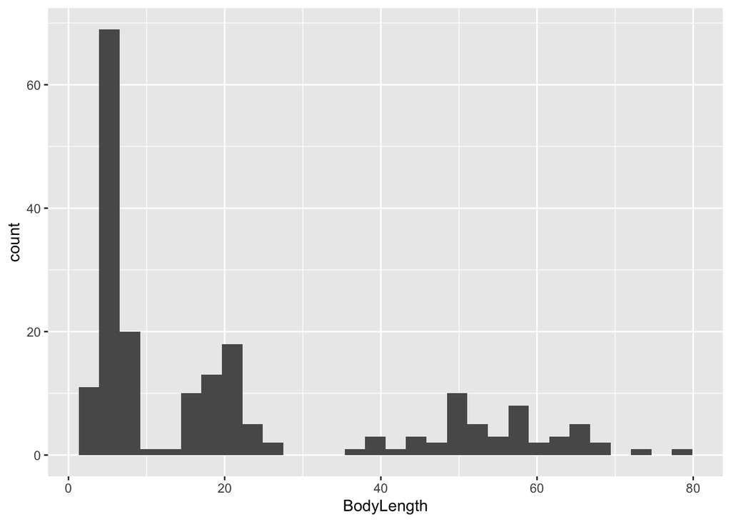

```r
#FIXME
ggplot(M, aes(BodyLength)) +
  geom_histogram()
```

There are some obvious groupings here, but we don’t know which species or sex the clusters represent. We need to separate both species and sex. One approach is to make a plot for each species with `fill` coding for sex (this is analogous to using color, but works better with histograms). Try this.

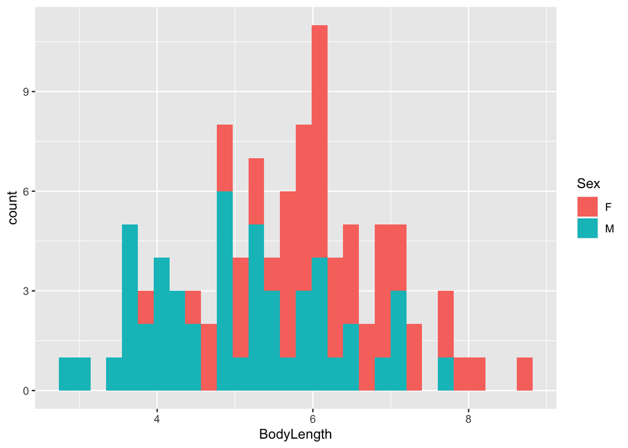

```r
#FIXME
M %>%
  filter(Species == 'Pardosa_ramulosa') %>%
  ggplot(aes(BodyLength, fill = Sex)) +
  geom_histogram()
```

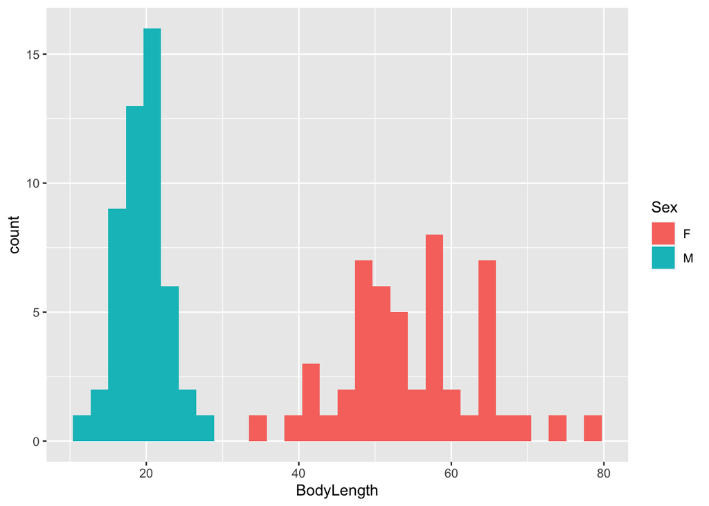

```r
M %>%
  filter(Species == 'Nephila_clavipes') %>%
  ggplot(aes(BodyLength, fill = Sex)) +
  geom_histogram()
```

You will get a message saying that “`stat_bin()` using `bins = 30`. Pick better value with `binwidth`.” That just means that you are using the default bin size for your histograms. In some situations, you would want to specify that value explicitly. For now, using the default value of 30 is fine. Later you can use the `binwidth` option to choose a different size.

We could also visualize all groups with `facet_grid()`. Here is an example:

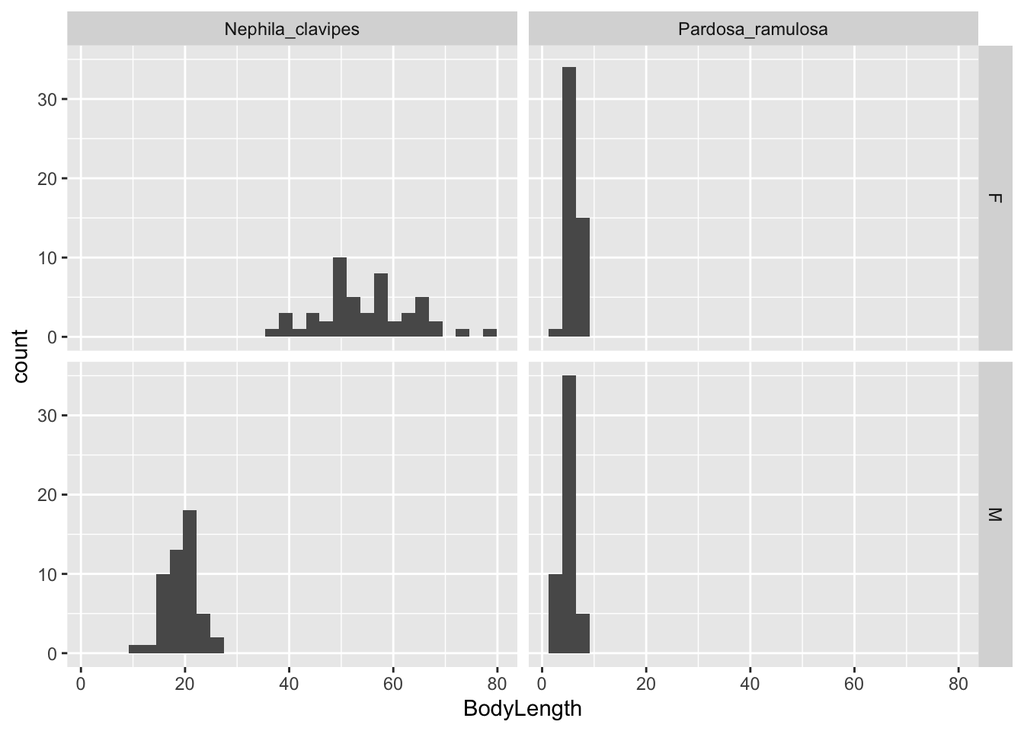

```r
ggplot(M, aes(BodyLength)) +
  geom_histogram() +
  facet_grid(Sex ~ Species)
```

`facet_grid()` can take 1 or two arguments. The argument before `~` splits by rows, and after `~` splits by columns. If you only want one or the other use `.`. See the lecture slides for an example.

With this you can clearly see SSD in *Nephila* but not in *Pardosa*.

## Scatterplot

You might be interested in the relationship between body length and body mass. Scatterplots are the most common way to visualize such bivariate relationships.

### Activity

Create a scatterplot of body length and body mass. Use color to show Sex and facet by Species. Put body length on the x axis. Add axis labels, but don’t worry about units for now.

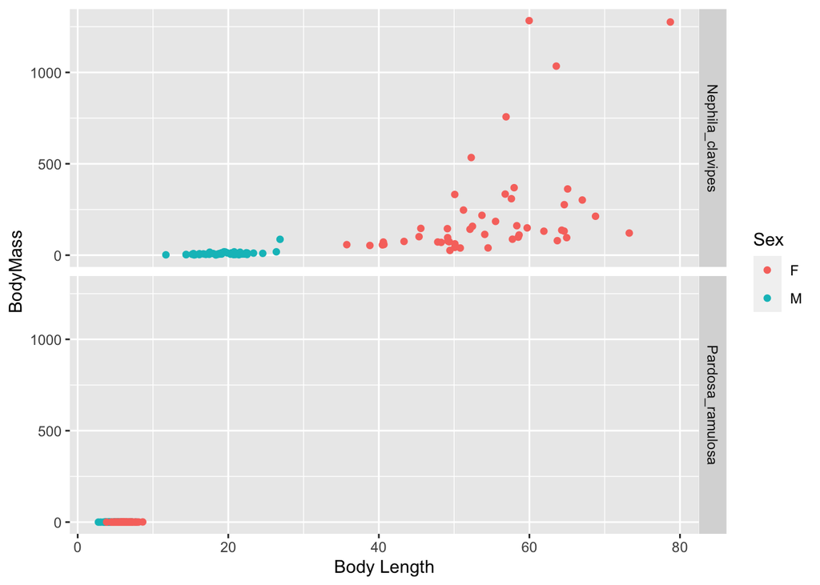

```r
# FIXME
ggplot(M, aes(x = BodyLength, y = BodyMass, color = Sex)) +
  geom_point() +
  facet_grid(Species ~ .) +
  labs(x = "Body Length", y = "BodyMass")
```

Describe the patterns you observe. Do you think this is a useful visualization? Why or why not?

> Not really that useful. The data for *Pardosa* is all smashed down to ~0 on the y axis, as is the male data for *Nephila*. The *Nephila* female are the only ones with any variation, which looks like it is increasing as body length increases.

Because body length and body mass are related by an exponential power, if we take advantage of the math of logarithms and log-transform the data, that will linearize the relationship. Ignoring the y-intercepts:

$$Mass \propto Length^b$$
$$\log(Mass) \propto b \log(Length)$$

Make two new variables that are the log10-transformations of body length and body mass using `mutate()` and plot the data again. Look at the help for `mutate` for hints. Then add new axis labels.

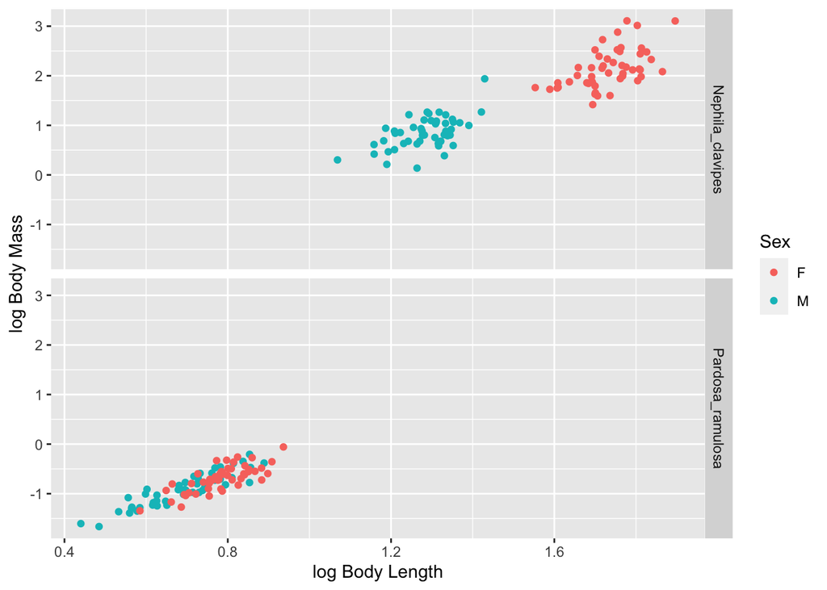

```r
#FIXME
M <- mutate(M, logMass = log10(BodyMass),
            logLength = log10(BodyLength))

# or with a pipe

M <- M %>% mutate(logMass = log10(BodyMass),
                  logLength = log10(BodyLength))

# Scatterplot
ggplot(M, aes(x = logLength, y = logMass, color = Sex)) +
  geom_point() +
  facet_grid(Species ~ .) +
  labs(x = "log Body Length", y = "log Body Mass")
```

What does this plot tell you? Do you think this is a more effective visualization of the data?

> There is a positive, linear relationship between log(mass) and log(body length). In *Pardosa*, the female and male distributions overlap almost completely. In *Nephila*, there is a large separation between the females and males.

Now add lines of best fit and transparency (`alpha`) to your points.

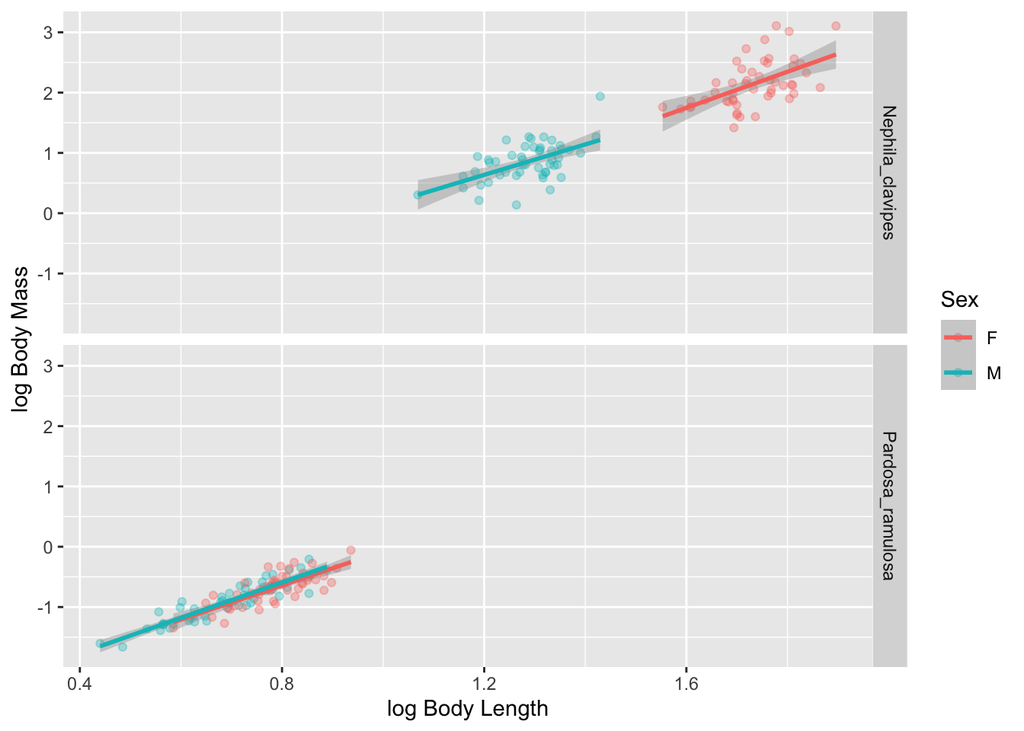

```r
#FIXME
ggplot(M, aes(x = logLength, y = logMass, color = Sex)) +
  geom_point(alpha = 1/3) +
  geom_smooth(method = 'lm') +
  facet_grid(Species ~ .) +
  labs(x = "log Body Length", y = "log Body Mass")
```

What do these regression lines tell you?

> The slopes of the lines are nearly identical, which suggests that the linear relationships between log length and log mass is probably equal across the four groups.
[^1]: There are >10,000 now
[^2]: Inside the call to `library()`, package names do not need to be quoted (but they can be without incident). `install.packages()`, on the other hand, expects to receive a string or vector of strings, so you do need quotes.